# 390R Homework 2

# 1 Exploring `flights` and `weather` dataset

**a.** How many observations and variables are in the `flights` and `weather` dataset?

```r
paste("There are", nrow(flights), "observation and", ncol(flights), "variables in flights dataset")
```

```
## [1] "There are 336776 observation and 19 variables in flights dataset"
```

```r
paste("There are", nrow(weather), "observation and", ncol(weather), "varibales in weather dataset")
```

```
## [1] "There are 26115 observation and 15 varibales in weather dataset"
```

**b.** Find out the meanings of `origin`, `carrier`, `dep_delay` and `dep_time` in the `flights` dataset and meanings of `visib`, `time_hour`, and `temp` in the `weather` dataset.

```r
print("In the flights dataset: ")
```

```
## [1] "In the flights dataset: "
```

```r
print("origin: origin of the airport")
```

```
## [1] "origin: origin of the airport"
```

```r
print("carrier: two letter carrier abbreviation")
```

```
## [1] "carrier: two letter carrier abbreviation"
```

```r
print("dep_delay: departure delays in minutes")
```

```
## [1] "dep_delay: departure delays in minutes"
```

```r
print("dep_time: actual departure time ")
```

```
## [1] "dep_time: actual departure time "
```

```r
print("In the weather dataset:")
```

```
## [1] "In the weather dataset:"
```

```r
print("visib: Visibility in miles")
```

```
## [1] "visib: Visibility in miles"
```

```r
print("time_hour: Data and hour of the recording as POSIXct date")
```

```
## [1] "time_hour: Data and hour of the recording as POSIXct date"
```

```r
print("temp: temperature in F")
```

```
## [1] "temp: temperature in F"
```

**c.** From the `dep_time` in the `flights` data, how many flights departed in the morning (before noon), in the afternoon (noon to 5:59 pm), and in the evening (6:00 pm or later), respectively? (Note: the data contain `NA` value which means missing. For this question, we will ignore the observations with missing departure time. Try the `na.rm` argument in the `sum()` function to get rid of the `NA` values.)

```r
# clean the data with NA value
f = flights[!is.na(flights$dep_time),]
morning_flight = f[f$dep_time>=1 & f$dep_time<=1159,]
afternoon_flight = f[f$dep_time>=1200 & f$dep_time<=1759,]
evening_flight = f[f$dep_time>=1800 & f$dep_time<=2400,]

print("There are 131023 flights departed in the morning")
```

```
## [1] "There are 131023 flights departed in the morning"
```

```r
print("There are 120761 flights departed in the afternoon")
```

```
## [1] "There are 120761 flights departed in the afternoon"
```

```r
print("There are 76737 flights departed in the evening")
```

```
## [1] "There are 76737 flights departed in the evening"
```

# 2 Scatterplot

The `flights` dataset is very large. We will be working with a subset of it in this question. Add a code chunk with the following codes. This will extract the data for observations with `carrier == AS` (Alaska Airlines). We will learn these codes later in the course.

```r
alaska_flights <- flights %>% filter(carrier == "AS") %>% filter(!is.na(arr_delay))
```

**a.** Make a scatterplot of `dep_delay` and `arr_delay` in the `alaska_flights` data. What do you find about the relationship between these two variable? What are some practical reasons for this relationship?

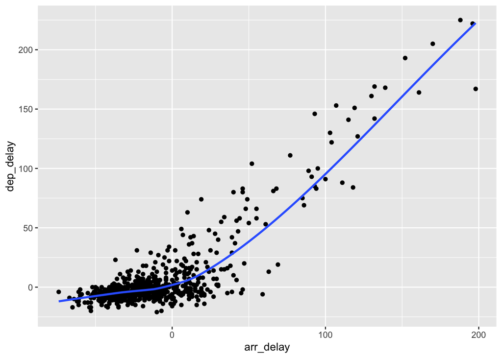

```r
library(ggplot2)
ggplot(data = alaska_flights, aes(x = arr_delay,y= dep_delay)) +
  geom_point() +
  geom_smooth(se = FALSE)
```

I noticed as departure delay times in minutes increases arrival delay times also increases. Reasons for this to happen because if a flight arrives late it would take longer for the flight to reach the destination, or wait extra longer for people checking in, or take some time to fuel the gasoline for the airplane. A lot of data are around (0,0), meaning most flights arrive and leave on time. **b.** There is a cluster of points near `(0, 0)`. What does (0, 0) correspond to in terms of the Alaska Air flights? Use the techniques learned from class to address this overplotting issue.

(0,0) in terms of the Alaska Air flights means there is zero departure delay for zero arrival delay in minute.

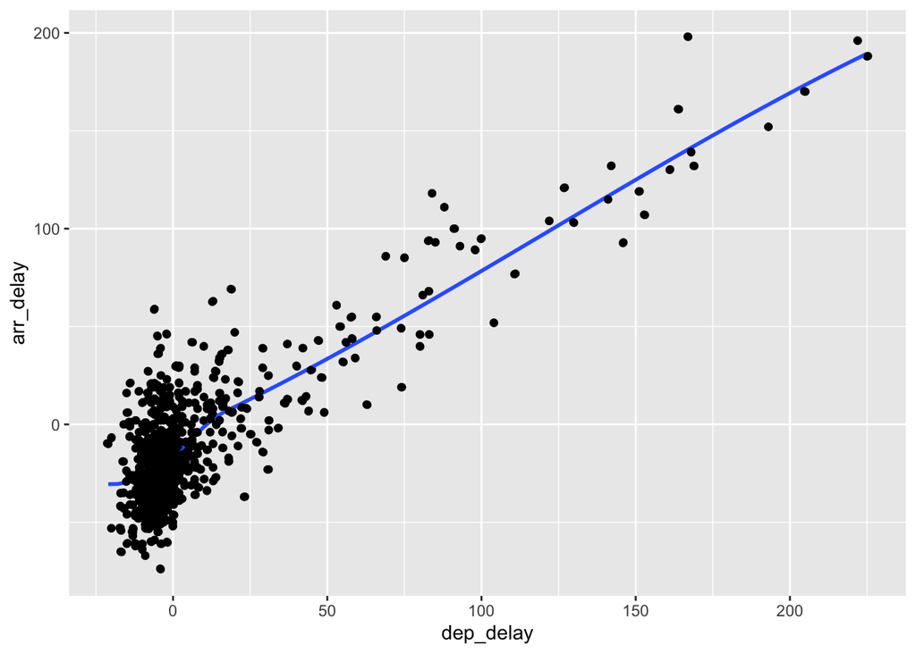

```r
ggplot(data = alaska_flights, aes(x = dep_delay,y= arr_delay)) +
  geom_point() +
  geom_smooth(se = FALSE) +
  geom_jitter()
```

# 3 Linegraphs

For this question, we will work on a subset of weather data. Add a chunk with the following codes to extract the weather data for EWR airport in January.

```r
early_january_weather <- weather %>% filter(origin == "EWR" & month == 1)
```

**a.** For the `early_january_weather` data, create a linegraph with `time_hour` on the x-axis and `temp` on the y-axis. What do you find from the plot?

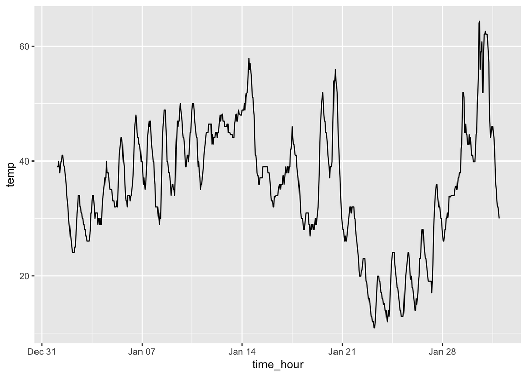

```r
ggplot(data = early_january_weather) +
  geom_line(mapping = aes(x = time_hour, y = temp))
```

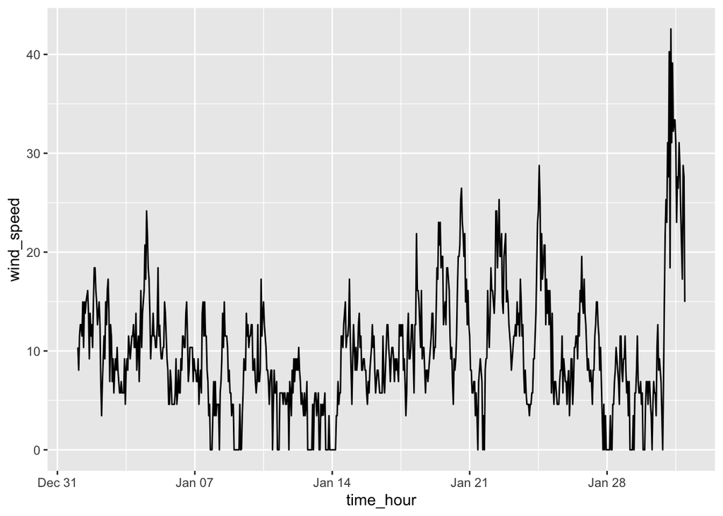

```r
ggplot(data = early_january_weather) +
  geom_line(mapping = aes(x = time_hour, y = wind_speed))
```

I noticed the windspeech from beginning of the year to the end of January, overall, is pretty low in mile per hour. Then it suddenly increases to a very high speed. I assume that the cold weather, snow, and fogs stop the flow of wind. Once it starts changing seasons, those barrie are gone, so more wind is able to flow into the air

# 4 Histograms

In this question, we will work with the weather_obs data created from the following codes. This removes the observations with missing data in the weather data.

```r
weather_obs <- weather %>% filter(!is.na(temp))
```

**a.** Create a histogram for `temp` in the `weather` data with white vertical borders for the bins. Describe the distribution of `temp` based on the histogram. You can try different bin settings.

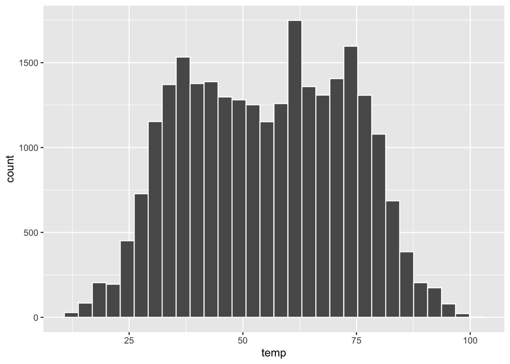

```r
ggplot(data = weather) +
  geom_histogram(mapping = aes(temp), color = "white", bins = 30)
```

**b.** Use faceted graph to plot the histograms for each of the 12 months. Compare the distributions of the temperature in different months.

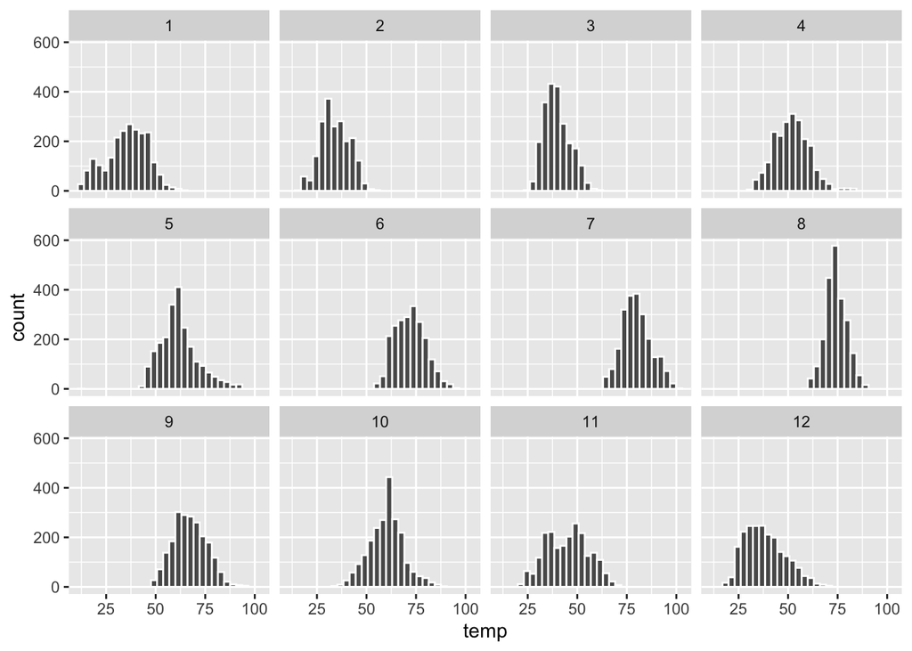

```r
ggplot(weather)+
  geom_histogram(mapping = aes(x=temp),color="white", bins = 30)+
      facet_wrap(~month)
```

# 5 Boxplots

**a.** Create a boxplot for `temp` in the `weather` data. Describe the distribution of `temp` based on the plot (you can use `summary()` function to get more information about `temp`)

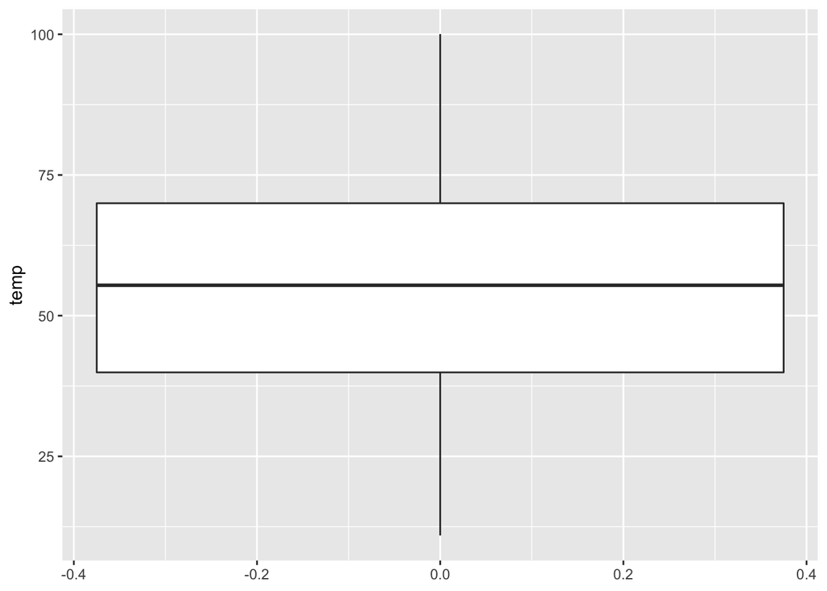

```r
ggplot(data = weather) +
  geom_boxplot(mapping = aes(y=temp))
```

```r
summary(weather$temp)
```

```
##    Min. 1st Qu.  Median    Mean 3rd Qu.    Max.    NA's
##   10.94   39.92   55.40   55.26   69.98  100.04       1
```

**b.** Try the following code, did you get what you expect? Make some changes to it to create a boxplot of temp split by month. Which months have the lowest and highest variability in temperature? (Hint: Check the type of `month` and search for functions to change its type.)

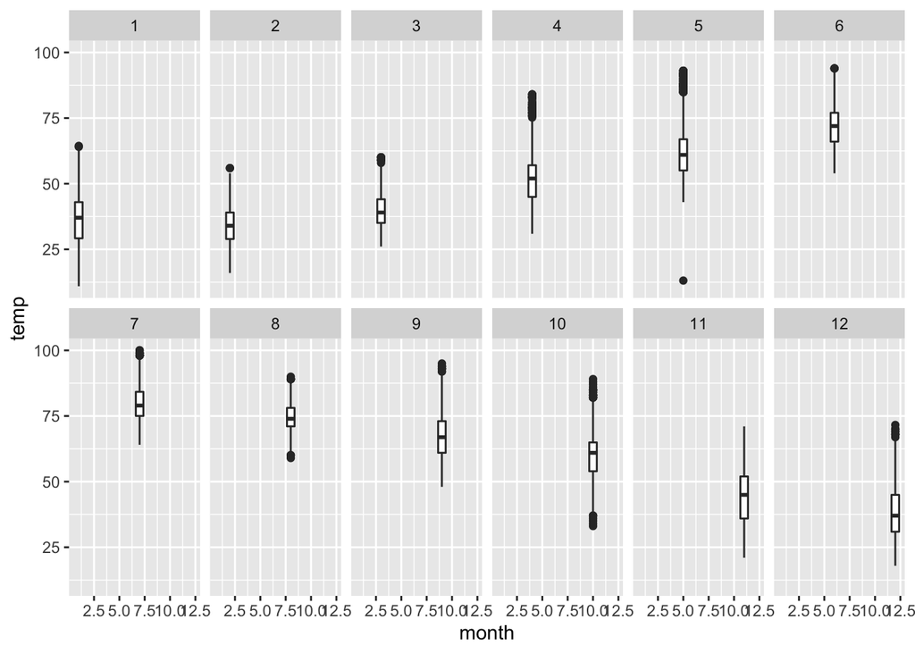

```r
ggplot(data = weather, mapping = aes(x = month, y = temp)) +
  geom_boxplot() +
  facet_wrap(~month, ncol=6)
```

```r
print("Eyespotting on the graph, I think the April, October, December have the highest variability in temperature, and August has lowest variability in temperature")
```

```
## [1] "Eyespotting on the graph, I think the April, October, December have the highest variability in temperature, and August has lowest variability in temperature"
```

# 6 Barplots

**a.** Create a barplot of `carrier` in the `flights` data. Which airline has the second highest share of flights (departed from NYC in 2013)? You may need to look at the `airlines` dataset to know which `airlines` correspond to which carrier codes.

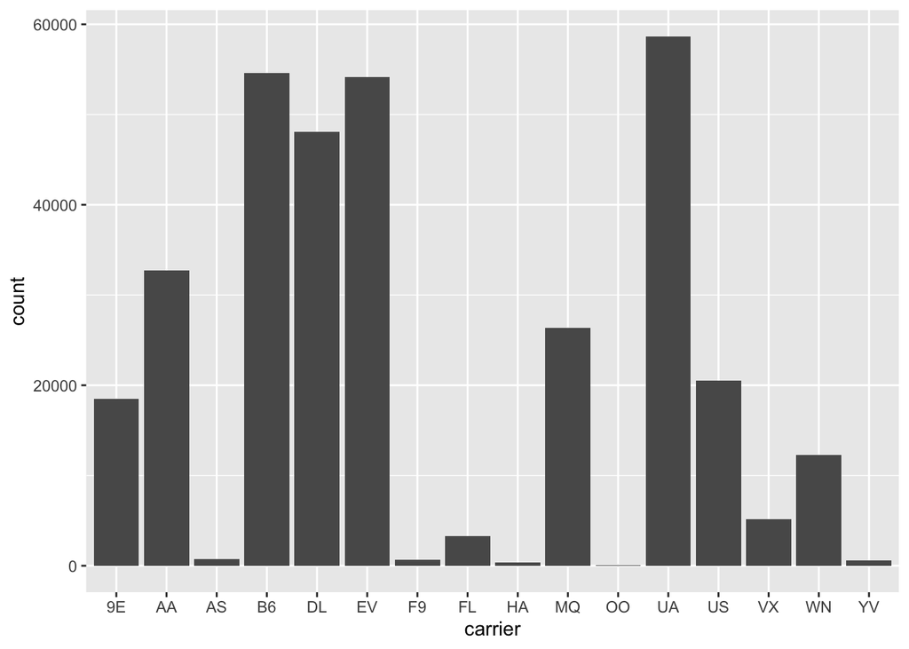

```r
ggplot(data = flights)+
  geom_bar(mapping = aes(x=carrier))
```

```r
print("JetBlue Airways has the second highest share of flights ")
```

```
## [1] "JetBlue Airways has the second highest share of flights "
```

**b.** There are three airports in NYC: LGA, JFK and EWR. Creat a barplot of `flights` split by `origin` with appropriate position adjustment. Find out the airlines that have a highest share of flights departed from the three airports, respectively.

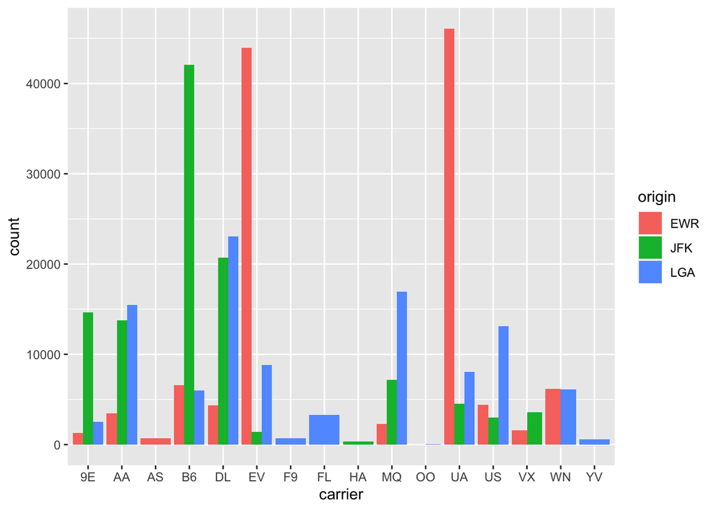

```r
ggplot(data = flights)+
  geom_bar(mapping = aes(x=carrier, fill = origin), position = "dodge")
```

```r
print("B6, Jetblue, has the highest share of flights departed from JFK, UA, United Airline, has the highest share of flights departed from EWR, DL, Delta Airline, has the highest share of flights departed from LGA.")
```

```
## [1] "B6, Jetblue, has the highest share of flights departed from JFK, UA, United Airline, has the highest share of flights departed from EWR, DL, Delta Airline, has the highest share of flights departed from LGA."
```

**c.** (optional) It is hard to get the exact number from the figures. Use `table()` function to obtain the number of flights for each airline and use `sort()` function to find the top 5 airlines. Then, find the top 5 airlines in terms of the flights departed from the three airports, respectively.

```r
sort(table(flights$carrier))
```

```
##
##    OO    HA    YV    F9    AS    FL    VX    WN    9E    US    MQ    AA    DL
##    32   342   601   685   714  3260  5162 12275 18460 20536 26397 32729 48110
##    EV    B6    UA
## 54173 54635 58665
```

```r
table(flights$carrier, flights$origin)
```

```
##
##        EWR   JFK   LGA
##   9E  1268 14651  2541
##   AA  3487 13783 15459
##   AS   714     0     0
##   B6  6557 42076  6002
##   DL  4342 20701 23067
##   EV 43939  1408  8826
##   F9     0     0   685
##   FL     0     0  3260
##   HA     0   342     0
##   MQ  2276  7193 16928
##   OO     6     0    26
##   UA 46087  4534  8044
##   US  4405  2995 13136
##   VX  1566  3596     0
##   WN  6188     0  6087
##   YV     0     0   601
```

```r
print("Top 5 airlines for JFK airport from highest to lowest: B6, DL, 9E, AA, MQ")
```

```
## [1] "Top 5 airlines for JFK airport from highest to lowest: B6, DL, 9E, AA, MQ"
```

```r
print("Top 5 airlines for EWR airpot from highest to lowest: UA, EV, B6, WN, US")
```

```
## [1] "Top 5 airlines for EWR airpot from highest to lowest: UA, EV, B6, WN, US"
```

```r
print("Top 5 airlines for LGA airpot from highest to lowest: DL, MQ, AA, US, EV")
```

```
## [1] "Top 5 airlines for LGA airpot from highest to lowest: DL, MQ, AA, US, EV"
```